# Abandono escolar nas redes estaduais: evidências para o debate sobre o Novo Ensino Médio

Rodrigo Travitzki

2023-05-25

# Achados principais

- Os fatores mais associados ao abandono escolar são o *nível socioeconômico dos alunos* e o *estado* (Unidade Federativa)
- O *Ensino à Distância (EAD)* se concentra em São Paulo e tende a **aumentar o abandono escolar**, mesmo controlando efeito do nível socioeconômico e outras variáveis. Esta é uma clara evidência contra um aspecto importante do Novo Ensino Médio, que é o estímulo à EAD.
- *Escolas de tempo integral* (ao menos 7h por dia) em geral apresentam **menor abandono escolar**, mesmo controlando efeito do estado, nível socioeconômico e outras variáveis. Esta é uma evidência a favor de um ponto importante do Novo Ensino Médio - o tempo integral - cuja origem na verdade é a meta 6 do [PNE](https://www.planalto.gov.br/ccivil_03/_ato2011-2014/2014/lei/l13005.htm) de 2014.
- A *adequação da formação docente* também é um fator que tende a **reduzir o abandono escolar**. Esta pode ser considerada uma evidência contra o “notório saber” como qualificação para a função de professor, como propõe o Novo Ensino Médio.

# Preparação do dados

Foi utilizada a base de dados de escolas de Ensino Médio, disponibilizada neste repositório, que junta dados do Censo Escolar 2022 com indicadores educacionais do INEP.

Neste estudo, incluímos apenas as escolas estaduais, que são 18.556 no total. De todas as variáveis disponíveis, selecionamos 29 candidatas a variável preditora do abandono escolar, a serem testadas na modelagem estatística. Maiores detalhes no código (clique no botão à direita).

Abaixo podemos ver algumas dessas variáveis e os respectivos percentuais relativos ao Brasil.

*clique para ver o código*

```r
library(tidyverse)
library(sjPlot)
library(SignifReg)
# library(reactable)
library(formattable)
library(knitr)
library(kableExtra)
# library(bslib)
# bslib::bs_theme()

ee=read_csv2('../dados/escolasEM2022.csv.gz')

# criar variaveis ------------------

ee=ee %>%
  mutate(tempo_integral = QT_MAT_MED_INT / QT_MAT_MED) # prpporcao matriculas
# ee[,c('QT_MAT_MED','QT_MAT_MED_INT','tempo_integral')] # check

vv=ee %>%
  select(starts_with('IN_MATERIAL')) %>%
  select(-IN_MATERIAL_PED_NENHUM)
ee$soma_MATERIAL_PED=apply(vv, 1, sum, na.rm=T)

vv=ee %>%
  select(starts_with('IN_PROF_'))
ee$soma_PROF_APOIO=apply(vv, 1, sum, na.rm=T)

# filtrar dados -------------------

# deixar apenas escolas estaduais
ee2 <- ee %>%
  filter(DEPENDENCIA=='Estadual')

# selecionar variaveis iniciais
ee2 <- ee2 %>%
  select(taxa_abandono,nivel_socioeconomico,IN_EJA,starts_with('IN_MEDIACAO_'),
         tem_atendimento_educacional_especializado=TP_AEE,IN_EXAME_SELECAO,
         adequacao_formacao_docente, esforco_docente, regularidade_docente,
         IN_MATERIAL_PED_DESPORTIVA:soma_PROF_APOIO, UF=SG_UF) %>%
  na.omit()

# tirar dos nomes
names(ee2)=gsub('IN_','',names(ee2))

# padronizar variaveis para modelos
ee3 <- ee2 %>%
  mutate_if(.predicate = is.numeric, .funs = function(x) as.numeric(scale(x))) %>%
  select(-MEDIACAO_PRESENCIAL)

# mostrar dados
descr=ee2 %>%
  select(-adequacao_formacao_docente, -esforco_docente,
         -regularidade_docente, -nivel_socioeconomico,
         -soma_MATERIAL_PED, -soma_PROF_APOIO, -UF) %>%
  skimr::skim()

descr=descr %>%
  select(variavel=skim_variable, percentual=numeric.mean)

descr$percentual[1]=descr$percentual[1] / 100
descr$percentual = formattable::percent(descr$percentual, digits = 0)

knitr::kable(descr) %>%
  kableExtra::kable_styling(full_width = F)
```

| variavel | percentual |
| --- | --- |
| taxa_abandono | 6% |
| EJA | 36% |
| MEDIACAO_PRESENCIAL | 100% |
| MEDIACAO_SEMIPRESENCIAL | 0% |
| MEDIACAO_EAD | 12% |
| tem_atendimento_educacional_especializado | 37% |
| EXAME_SELECAO | 4% |
| MATERIAL_PED_DESPORTIVA | 80% |
| MATERIAL_PED_ARTISTICAS | 44% |
| MATERIAL_PED_JOGOS | 67% |
| MATERIAL_PED_DIFUSAO | 66% |
| MATERIAL_PED_MULTIMIDIA | 54% |
| MATERIAL_PED_CIENTIFICO | 42% |
| MATERIAL_PED_NENHUM | 11% |
| PROF_COORDENADOR | 34% |
| PROF_ADMINISTRATIVOS | 80% |
| PROF_PSICOLOGO | 2% |
| COMPUTADOR | 95% |
| INTERNET_APRENDIZAGEM | 80% |
| INTERNET | 97% |
| PATIO_COBERTO | 62% |
| ALMOXARIFADO | 58% |
| tempo_integral | 24% |

Note que 12% das escolas têm EAD, 24% tem tempo integral e 37% tem atendimento educacional especializado. Além disso, embora 97% tenha acesso à internet, apenas 80% disponibiliza a internet para aprendizagem dos alunos. E há 11% de escolas sem nenhum material pedagógico.

# Método

Utilizamos modelos de regressão linear tendo a taxa de abandono escolar como variável resposta. As variáveis acima e mais algumas, 29 ao todo, foram inseridas em um modelo inicial. Esse modelo passou por um processo de otimização, com critérios objetivos (AIC e p), para seleção das variáveis mais associadas ao abandono escolar (mais detalhes no código). As variáveis foram padronizadas para permitir a comparação dos coeficientes dos modelos.

O método utilizado não permite a inferência de causalidade, como nos métodos experimentais e quase-experimentais. Mas os resultados servem como evidências que podem ser complementadas por outras informações, pela lógica e pela teoria.

```r
# lm1 <- lm(taxa_abandono ~ ., data = ee3)
# # otimizar modelo segundo AIC
# lm1 <- step(lm1, trace = FALSE)
# # ajuste fino retirando variaveis com p-valor alto
# lm1 <- SignifReg::SignifReg(lm1, direction = "both", criterion = 'p-value')
#
# save(lm1, file = 'lm1.rda')
load('lm1.rda')
```

# Fatores mais associados ao abandono escolar

A figura abaixo mostra mostra o grau de associação das diferentes variáveis no modelo final, que também inclui o estado (não está na figura mas está no Anexo).

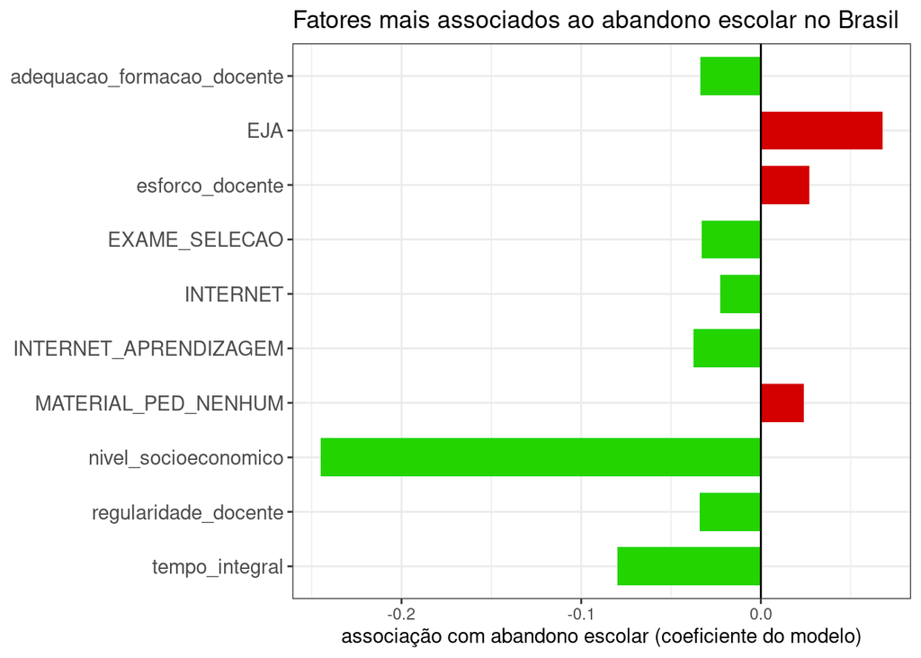

```r
# pegar coeficientes do modelo
cf=coef(lm1)[2:11]
cf=data.frame(variavel=names(cf), cf)
cf$cor2='1ajuda'
cf$cor2[cf$cf>0]='2piora'

# plotar coef
cf %>% ggplot(aes(x=cf, y= reorder(variavel, desc(variavel)), fill=cor2))+
  geom_bar(stat = 'identity', width = .7)+
  scale_fill_manual(values = c('#23d400', '#d40000'))+
  # scale_y_discrete(limits = rev(levels(cf$variavel)))+
  labs(x='associação com abandono escolar (coeficiente do modelo)', y=NULL, title = 'Fatores mais associados ao abandono escolar no Brasil')+
  geom_vline(xintercept=0)+
  theme_bw()+
  theme(legend.position = 'none',
        axis.text.y = element_text(size = 11))
```

É impressionante como o nível socioeconômico se destaca de todos os outros fatores. Isso significa que, nas escolas com alunos mais pobres, o abandono escolar tende a ser muito maior, mesmo quando controlamos todas as outras variáveis. Em parte, isso reflete limitações da escola e da sociedade, mas também reforça a importância das políticas de apoio e políticas afirmativas para que os alunos não abandonem o Ensino Médio.

O segundo fator mais importante é a proporção de alunos de ensino médio que estudam em tempo integral (no mínimo 7 horas por dia). Esta é uma evidência importante a favor de um dos aspectos do Novo Ensino Médio, que na verdade tem sua origem na meta 6 do [Plano Nacional de Educação](https://www.planalto.gov.br/ccivil_03/_ato2011-2014/2014/lei/l13005.htm), de 2014. É importante frisar que esses resultados não excluem a possibilidade de que a existência de escolas integrais e não integrais aumente a desigualdade no sistema educacional, o que é outra questão.

Na figura notamos também que os três indicadores sobre professores estão presentes. A adequação da formação e a regularidade docente contribuem para a diminuição do abandono escolar. Já o esforço docente aumenta o abandono, o que mostra a importância de boas condições de trabalho para que o trabalho possa ser bem feito.

# Educação à Distância e abandono escolar

Como vemos na tabela abaixo, quase todas as escolas com EAD estão no Estado de São Paulo. Exatamente 97% fazendo a conta. E dentro do Estado de São Paulo, 57% das escolas tem EAD. Talvez haja subnotificação em outros estados, mas isso não vem ao caso no momento.

```r
agg = ee2 %>%
  group_by(UF) %>%
  summarise(percentual_de_escolas_com_EAD=round(mean(MEDIACAO_EAD, na.rm = T),3),
            numero_de_escolas_com_EAD=sum(MEDIACAO_EAD, na.rm = T)) %>%
  filter(numero_de_escolas_com_EAD!=0)

agg1 = ee2 %>%
  summarise(percentual_de_escolas_com_EAD=round(mean(MEDIACAO_EAD, na.rm = T),3),
            numero_de_escolas_com_EAD=sum(MEDIACAO_EAD, na.rm = T)) %>%
  filter(numero_de_escolas_com_EAD!=0) %>%
  mutate(UF='Total')

agg1 = bind_rows(agg, agg1)

agg1$percentual_de_escolas_com_EAD = formattable::percent(agg1$percentual_de_escolas_com_EAD, digits = 1)

# prop.table(agg1$mediacao_EAD_soma) # sp=97%

knitr::kable(agg1) %>%
  kableExtra::kable_styling(full_width = F)
```

| UF | percentual_de_escolas_com_EAD | numero_de_escolas_com_EAD |
| --- | --- | --- |
| DF | 1.0% | 1 |
| GO | 6.4% | 45 |
| MA | 0.1% | 1 |
| MS | 0.7% | 2 |
| PE | 0.1% | 1 |
| PI | 1.4% | 7 |
| RJ | 0.2% | 2 |
| SP | 56.9% | 2187 |
| Total | 12.1% | 2246 |

Sendo assim, partindo desses dados, a melhor estratégia para analisar a Educação à Distância é ajustar um modelo apenas para as escolas de São Paulo. Usamos o mesmo método de otimização aplicado para as escolas brasileiras. As variáveis mais associadas ao abandono escolar em São Paulo podem ser vistas na figura abaixo.

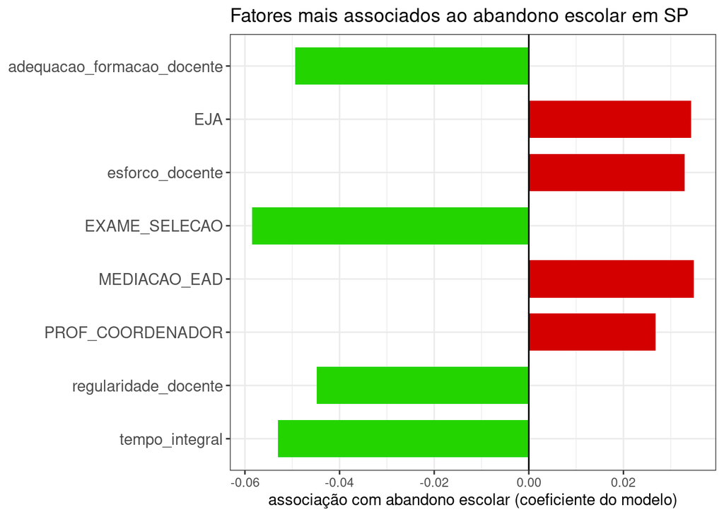

```r
# filtrar
ee4 <- ee3 %>%
  filter(UF=='SP') %>%
  select(-UF)

# repetir metodo

# lm2 <- lm(taxa_abandono ~ ., data = ee4)
# # otimizar modelo segundo AIC
# lm2 <- step(lm2, trace = FALSE)
# # ajuste fino retirando variaveis com p-valor alto
# lm2 <- SignifReg::SignifReg(lm2, direction = "both", criterion = 'p-value')
#
# save(lm2, file = 'lm2.rda')
load('lm2.rda')

# pegar coeficientes
cf=coef(lm2)[2:9]
cf=data.frame(variavel=names(cf), cf)
cf$cor2='1ajuda'
cf$cor2[cf$cf>0]='2piora'

# plotar coef
cf %>% ggplot(aes(x=cf, y= reorder(variavel, desc(variavel)), fill=cor2))+
  geom_bar(stat = 'identity', width = .7)+
  scale_fill_manual(values = c('#23d400', '#d40000'))+
  # scale_y_discrete(limits = rev(levels(cf$variavel)))+
  labs(x='associação com abandono escolar (coeficiente do modelo)', y=NULL, title = 'Fatores mais associados ao abandono escolar em SP')+
  geom_vline(xintercept=0)+
  theme_bw()+
  theme(legend.position = 'none',
        axis.text.y = element_text(size = 11))
```

Curiosamente, o fator mais associado é a presença de um exame de seleção, que pode ser tanto uma prova quanto uma análise de currículo. O que é um pouco natural por um lado, mas por outro lado aponta uma forte lógica de mercado numa rede pública, o que levanta questões.

Note como a mediação EAD está associada ao aumento do abandono escolar. Isso é importante no contexto da reforma do Ensino Médio. Vale lembrar que São Paulo tem uma rede estadual muito madura e autônoma, não dá para dizer que houve problemas de implementação da EAD pela falta de coordenação do Governo Federal, nem tampouco pela pandemia, que impulsionou a EAD como nunca. Não parece se tratar de um problema de implementação, mas sim de concepção.

# Anexo: tabelas com detalhes dos modelos

## Brasil

```r
# mostrar resultados com escalas padronizadas
sjPlot::tab_model(lm1, show.ci=FALSE)
```

|  | taxa_abandono |  |
| --- | --- | --- |
| Predictors | Estimates | p |
| (Intercept) | 0.16 | 0.080 |
| nivel socioeconomico | -0.25 | **<0.001** |
| EJA | 0.07 | **<0.001** |
| EXAME SELECAO | -0.03 | **<0.001** |
| adequacao formacao docente | -0.03 | **<0.001** |
| esforco docente | 0.03 | **0.006** |
| regularidade docente | -0.03 | **<0.001** |
| MATERIAL PED NENHUM | 0.02 | **0.004** |
| INTERNET APRENDIZAGEM | -0.04 | **<0.001** |
| INTERNET | -0.02 | **0.005** |
| tempo integral | -0.08 | **<0.001** |
| UF [AL] | -0.37 | **0.001** |
| UF [AM] | -0.29 | **0.003** |
| UF [AP] | 0.13 | 0.288 |
| UF [BA] | 0.41 | **<0.001** |
| UF [CE] | -0.70 | **<0.001** |
| UF [DF] | -0.16 | 0.197 |
| UF [ES] | -0.78 | **<0.001** |
| UF [GO] | -0.66 | **<0.001** |
| UF [MA] | -0.68 | **<0.001** |
| UF [MG] | -0.02 | 0.828 |
| UF [MS] | -0.21 | **0.043** |
| UF [MT] | 0.33 | **0.001** |
| UF [PA] | 0.08 | 0.447 |
| UF [PB] | 0.22 | **0.035** |
| UF [PE] | -0.90 | **<0.001** |
| UF [PI] | 0.11 | 0.278 |
| UF [PR] | -0.32 | **0.001** |
| UF [RJ] | -0.12 | 0.202 |
| UF [RN] | 0.61 | **<0.001** |
| UF [RO] | -0.06 | 0.574 |
| UF [RR] | 0.46 | **<0.001** |
| UF [RS] | 0.66 | **<0.001** |
| UF [SC] | -0.04 | 0.686 |
| UF [SE] | -0.53 | **<0.001** |
| UF [SP] | -0.26 | **0.005** |
| UF [TO] | -0.61 | **<0.001** |
| Observations | 18556 |  |
| R<sup>2</sup> / R<sup>2</sup> adjusted | 0.262 / 0.261 |  |

## São Paulo

```r
# mostrar resultados com escalas padronizadas
sjPlot::tab_model(lm2, show.ci=FALSE)
```

|  | taxa_abandono |  |
| --- | --- | --- |
| Predictors | Estimates | p |
| (Intercept) | -0.41 | **<0.001** |
| EJA | 0.03 | **0.003** |
| MEDIACAO EAD | 0.03 | **0.007** |
| EXAME SELECAO | -0.06 | **<0.001** |
| adequacao formacao docente | -0.05 | **0.001** |
| esforco docente | 0.03 | **0.037** |
| regularidade docente | -0.04 | **0.001** |
| PROF COORDENADOR | 0.03 | **0.011** |
| tempo integral | -0.05 | **0.008** |
| Observations | 3842 |  |
| R<sup>2</sup> / R<sup>2</sup> adjusted | 0.095 / 0.094 |  |